# R02_1 Paid Maternity Leave

Jilung Hsieh

2019/9/2

# 1 Case: Paid Maternal Leave

- 本案例將利用R來重製華盛頓郵報在2016/08/13的一篇談論美國婦女產假支薪情形的報導。這個案例中將會應用到data.frame和基本的繪圖與資料摘要方法。The case adaped Washington Post’s paid maternity leave as an exmaple to introduce basic skill of data.frame, plotting, and data mamipulation.
- 原始新聞來源：https://www.washingtonpost.com/news/worldviews/wp/2016/08/13/the-world-is-getting-better-at-paid-maternity-leave-the-u-s-is-not/?tid=sm_tw&utm_term=.f8cd50280326#comments

# 2 Reading .xlsx by readxl package

- readxl也包含在tidyverse的套件集中，所以應該已經在前次安裝過，不用特別安裝。

```r
# Import readxl package
library(readxl)
options(stringsAsFactors = FALSE)
```

# 3 Reading Excel

```r
# Use read_excel() to convert excel sheet to data.frame
df <- read_excel("data/WORLD-MACHE_Gender_6.8.15.xls", "Sheet1", col_names=T)
```

# 4 Previewing data by `View()`, `class()`, `dim()`, `str()`, `summary()` and `names()`

```r
# View(df)
class(df)       # [1] "tbl_df"     "tbl"        "data.frame"
```

```
## [1] "tbl_df"     "tbl"        "data.frame"
```

```r
dim(df)
```

```
## [1] 197 156
```

```r
# Show names of variables (vectors, columns) by names()
names(df)
```

```
##   [1] "country"           "iso2"              "iso3"
##   [4] "region"            "wb_econ"           "matleave_95"
##   [7] "matleave_96"       "matleave_97"       "matleave_98"
##  [10] "matleave_99"       "matleave_00"       "matleave_01"
##  [13] "matleave_02"       "matleave_03"       "matleave_04"
##  [16] "matleave_05"       "matleave_06"       "matleave_07"
##  [19] "matleave_08"       "matleave_09"       "matleave_10"
##  [22] "matleave_11"       "matleave_12"       "matleave_13"
##  [25] "matleave_wrr_95"   "matleave_wrr_96"   "matleave_wrr_97"
##  [28] "matleave_wrr_98"   "matleave_wrr_99"   "matleave_wrr_00"
##  [31] "matleave_wrr_01"   "matleave_wrr_02"   "matleave_wrr_03"
##  [34] "matleave_wrr_04"   "matleave_wrr_05"   "matleave_wrr_06"
##  [37] "matleave_wrr_07"   "matleave_wrr_08"   "matleave_wrr_09"
##  [40] "matleave_wrr_10"   "matleave_wrr_11"   "matleave_wrr_12"
##  [43] "matleave_wrr_13"   "bf_dur_95"         "bf_dur_96"
```

[output cut: 37 more lines]

# 5 Selecting essential variables

```r
# Select the 3rd and 6th to 24th columns
matleave <- df[ , c(3, 6:24)]

# Use class(), dim(), and str() to inspect the data
class(matleave)
```

```
## [1] "tbl_df"     "tbl"        "data.frame"
```

```r
dim(matleave)
```

```
## [1] 197  20
```

```r
str(matleave)
```

```
## Classes 'tbl_df', 'tbl' and 'data.frame':    197 obs. of  20 variables:
##  $ iso3       : chr  "AFG" "ALB" "DZA" "AND" ...
##  $ matleave_95: num  2 5 3 2 2 2 2 3 1 5 ...
##  $ matleave_96: num  2 5 3 2 2 2 2 3 1 5 ...
##  $ matleave_97: num  2 5 3 2 2 2 2 3 1 5 ...
##  $ matleave_98: num  2 5 3 2 2 2 2 3 1 5 ...
##  $ matleave_99: num  2 5 3 2 2 2 2 3 1 5 ...
##  $ matleave_00: num  2 5 3 3 2 2 2 3 1 5 ...
##  $ matleave_01: num  2 5 3 3 2 2 2 3 1 5 ...
##  $ matleave_02: num  2 5 3 3 2 2 2 3 1 5 ...
##  $ matleave_03: num  2 5 3 3 2 2 2 3 1 5 ...
##  $ matleave_04: num  2 5 3 3 2 2 2 5 1 5 ...
##  $ matleave_05: num  2 5 3 3 2 2 2 5 1 5 ...
##  $ matleave_06: num  2 5 3 3 2 2 2 5 1 5 ...
##  $ matleave_07: num  2 5 3 3 2 2 2 5 1 5 ...
##  $ matleave_08: num  2 5 3 3 2 2 2 5 1 5 ...
##  $ matleave_09: num  2 5 3 3 2 2 2 5 1 5 ...
##  $ matleave_10: num  2 5 3 3 2 2 2 5 NA 5 ...
##  $ matleave_11: num  2 5 3 3 2 2 2 5 3 5 ...
##  $ matleave_12: num  2 5 3 3 2 2 2 5 3 5 ...
##  $ matleave_13: num  2 5 3 3 2 2 2 5 3 5 ...
```

# 6 Checking and Replacing NAs

- `NA: Not Available`
- `v[is.na(v)]` will select all NA cells
- 以0取代NA的資料格。避免繪圖產生錯誤
- `sum(is.na(matleave))`的目的是檢測還有沒有NA值。如果有的話`is.na()`就會是`TRUE`，那麼加總後，如果不是0，那就代表還有NA。

```r
# is.na() to indicate each element is NA or NOT(TRUE/FALSE)
head(is.na(matleave), n=20)
```

```
##        iso3 matleave_95 matleave_96 matleave_97 matleave_98 matleave_99
##  [1,] FALSE       FALSE       FALSE       FALSE       FALSE       FALSE
##  [2,] FALSE       FALSE       FALSE       FALSE       FALSE       FALSE
##  [3,] FALSE       FALSE       FALSE       FALSE       FALSE       FALSE
##  [4,] FALSE       FALSE       FALSE       FALSE       FALSE       FALSE
##  [5,] FALSE       FALSE       FALSE       FALSE       FALSE       FALSE
##  [6,] FALSE       FALSE       FALSE       FALSE       FALSE       FALSE
##  [7,] FALSE       FALSE       FALSE       FALSE       FALSE       FALSE
##  [8,] FALSE       FALSE       FALSE       FALSE       FALSE       FALSE
##  [9,] FALSE       FALSE       FALSE       FALSE       FALSE       FALSE
## [10,] FALSE       FALSE       FALSE       FALSE       FALSE       FALSE
## [11,] FALSE       FALSE       FALSE       FALSE       FALSE       FALSE
## [12,] FALSE       FALSE       FALSE       FALSE       FALSE       FALSE
## [13,] FALSE       FALSE       FALSE       FALSE       FALSE       FALSE
## [14,] FALSE       FALSE       FALSE       FALSE       FALSE       FALSE
```

[output cut: 69 more lines]

```r
# Assign 0 to those NA data
matleave[is.na(matleave)] <- 0

# anyNA() to check if there are still NA cells.
anyNA(matleave)
```

```
## [1] FALSE
```

```r
# sum(is.na()) to count the number of NA
sum(is.na(matleave))
```

```
## [1] 0
```

# 7 Filtering data

# 8 Filtered by the last year value

```r
# Use logical comparison to see if the last year equals to 5
# Assign matching data to var m5
m5 <- matleave[matleave$'matleave_13'==5, ]

# nrow() to count matching data
nrow(m5)
```

```
## [1] 34
```

```r
# Is it possible to use length() to check the data length?
# matleave$'matleave_13'
# matleave$'matleave_13'==5
# length(matleave$'matleave_13'==5)
```

## 8.1 Filtered data by the first year value

```r
# filter rows whose 'matleave_95' is 5, and assign to var m55
m55<- m5[m5$'matleave_95'==5,]

# filter rows whose 'matleave_95' is not 5, and assign to var m05
m05<- m5[m5$'matleave_95'!=5,]
```

# 9 Plotting

- Plotting the second rows and all columns except 1st column
- **Question** 為何要`unlist()`？請試著執行`barplot(matleave[2, -1])`這個沒有`unlist()`的版本，看看會有什麼錯誤訊息。資料結構有何差異呢？
- 嘗試用`class()`或`str()`嘗試觀察沒有`unlist()`版本的資料，看看資料型態和有`unlist()`的會有何不同？

## 9.1 Plotting one line

```r
# barplot() the second row of m55
# barplot(m55[2, ])       # raise error

# barplot() the second row when neglecting the first column
# barplot(m55[2, -1])     # raise error

# Take a look at the data type of matleave[2, ]
class(matleave[2, -1])
```

```
## [1] "tbl_df"     "tbl"        "data.frame"
```

```r
class(unlist(matleave[2, -1]))
```

```
## [1] "numeric"
```

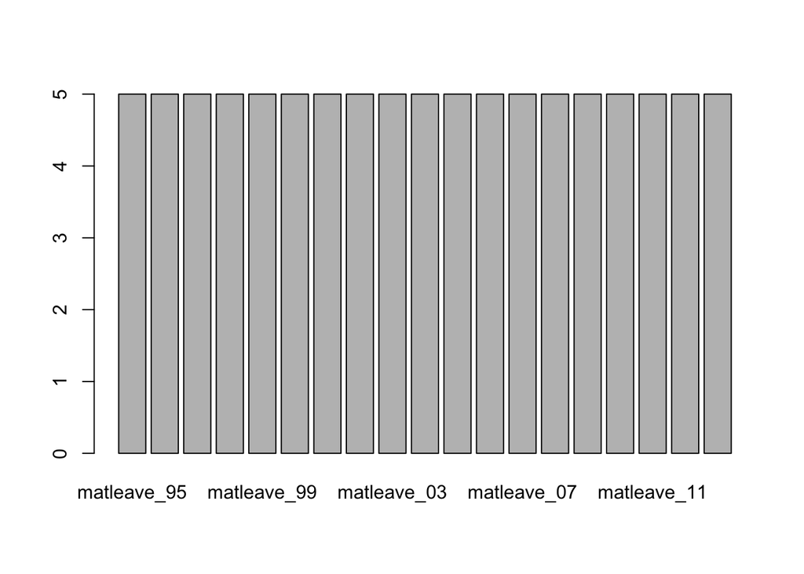

```r
# unlist() to convert a single row data.frame to a vector for barplot()
barplot(unlist(m55[2, -1]))
```

- Testing

```r
# View(matleave[1]) # select the 1st variable
# View(matleave[ ,1]) # select the 1st column
# View(matleave[1, ]) # select the 1st row

class(m55[1])       # "tbl_df"     "tbl"        "data.frame"
```

```
## [1] "tbl_df"     "tbl"        "data.frame"
```

```r
class(m55[ ,1]) # "tbl_df"     "tbl"        "data.frame"
```

```
## [1] "tbl_df"     "tbl"        "data.frame"
```

```r
class(m55[1, ]) # "tbl_df"     "tbl"        "data.frame"
```

```
## [1] "tbl_df"     "tbl"        "data.frame"
```

```r
class(m55$iso3) # character (vector)
```

```
## [1] "character"
```

## 9.2 More arguments (args)

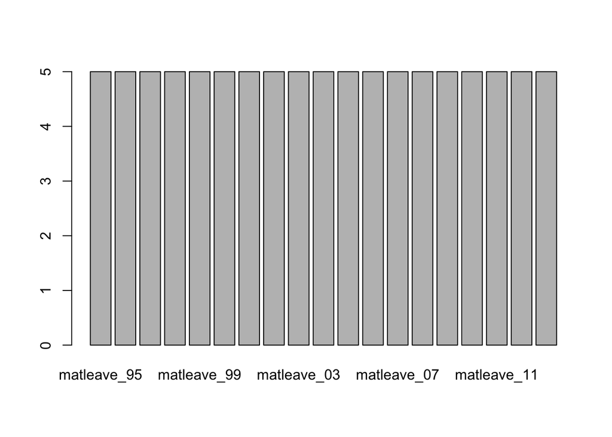

```r
# barplot() the unlisted second row (neglecting the first col)
barplot(unlist(m55[2, -1]))
```

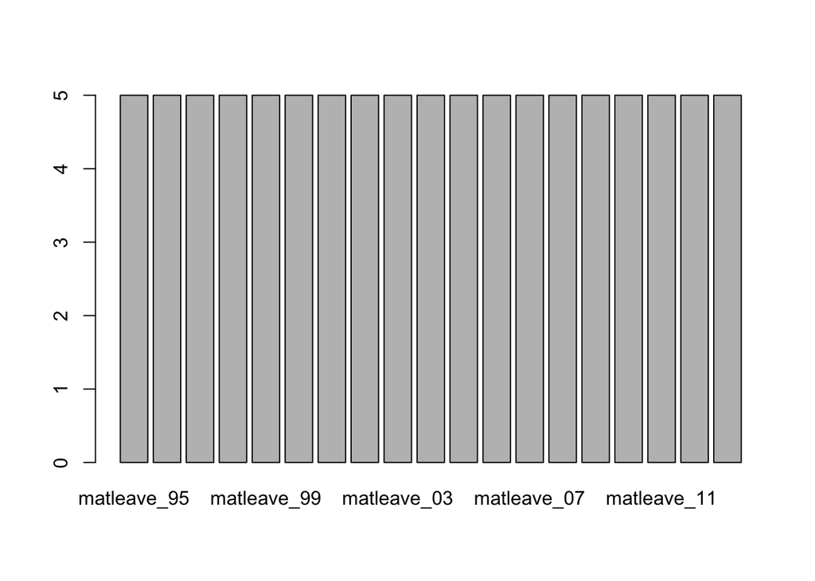

```r
# use ?barplot to know more argument of the function.
?barplot

# Add arguments ylim, space, border, and axat/yaxt one by one to barplot()
barplot(unlist(m55[2, -1]), ylim=c(0, 5))
```

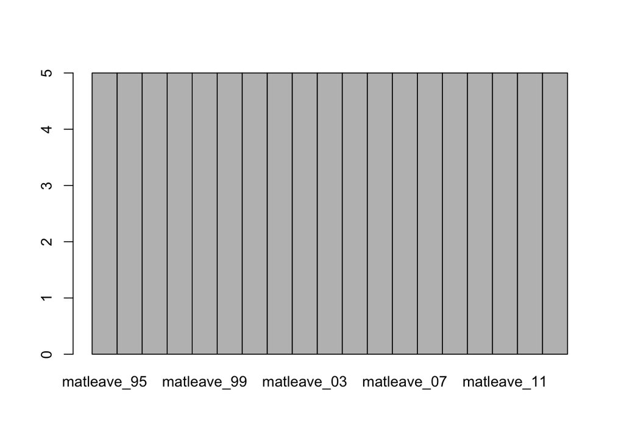

```r
barplot(unlist(m55[2, -1]), ylim=c(0, 5), space=0)
```

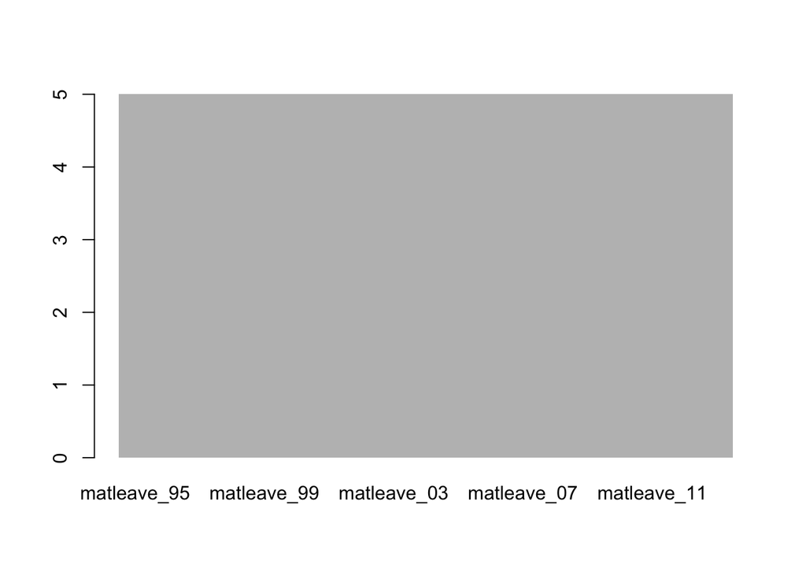

```r
barplot(unlist(m55[2, -1]), ylim=c(0, 5), space=0, border=NA)
```

```r
barplot(unlist(m55[2, -1]), ylim=c(0, 5), space=0, border=NA, xaxt="n", yaxt="n")
```

[output not shown]

## 9.3 Plotting multiple lines

- 底下可以看見每一行非常相似且一致的特徵，僅有`matleave`內的索引由1被列出至6。因此，最好的方法是用迴圈（for-loop）的方式將相同的程式碼，從1~6之間做六次。

```r
# plot the first row
barplot(unlist(m55[1, -1]), ylim=c(0, 5), space=0, border=NA, xaxt="n", yaxt="n")

# plot the second to 6th rows
barplot(unlist(m55[2, -1]), ylim=c(0, 5), space=0, border=NA, xaxt="n", yaxt="n")
```

[output not shown]

```r
barplot(unlist(m55[3, -1]), ylim=c(0, 5), space=0, border=NA, xaxt="n", yaxt="n")
barplot(unlist(m55[4, -1]), ylim=c(0, 5), space=0, border=NA, xaxt="n", yaxt="n")
barplot(unlist(m55[5, -1]), ylim=c(0, 5), space=0, border=NA, xaxt="n", yaxt="n")
barplot(unlist(m55[6, -1]), ylim=c(0, 5), space=0, border=NA, xaxt="n", yaxt="n")
```

[output not shown]

## 9.4 for-loop to plot multiple lines

```r
# use for loop and use i as index to barplot multiple subgraphs
for(i in 1:6){
  barplot(unlist(m55[i, -1]), ylim=c(0, 5), space=0, border=NA, xaxt="n", yaxt="n")
}
```

[output not shown]

## 9.5 5.5 Sub-plots

- Check `?par` to get paremeters of plotting
- `**mai**`: A numerical vector of the form c(bottom, left, top, right) which gives the margin size specified in inches.
- `**mfcol, mfrow**`:A vector of the form c(nr, nc). Subsequent figures will be drawn in an nr-by-nc array on the device by columns (mfcol), or rows (mfrow), respectively.

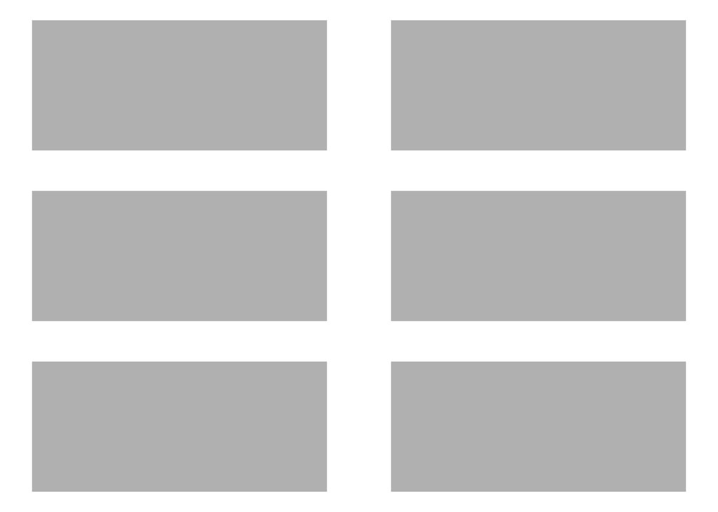

```r
# use ?par to get more plotting parameters
?par

# use par() to set-up the layout of subgraphs
# use the parameter main=c(0.2, 0.2, 0.2, 0.2) to thrink the padding of figures.
par(mfrow=c(3,2), mai= c(0.2, 0.2, 0.2, 0.2))
for(i in 1:6){
  barplot(unlist(m55[i, -1]), ylim=c(0, 5), space=0, border=NA, xaxt="n", yaxt="n")
}
```

## 9.6 Testing

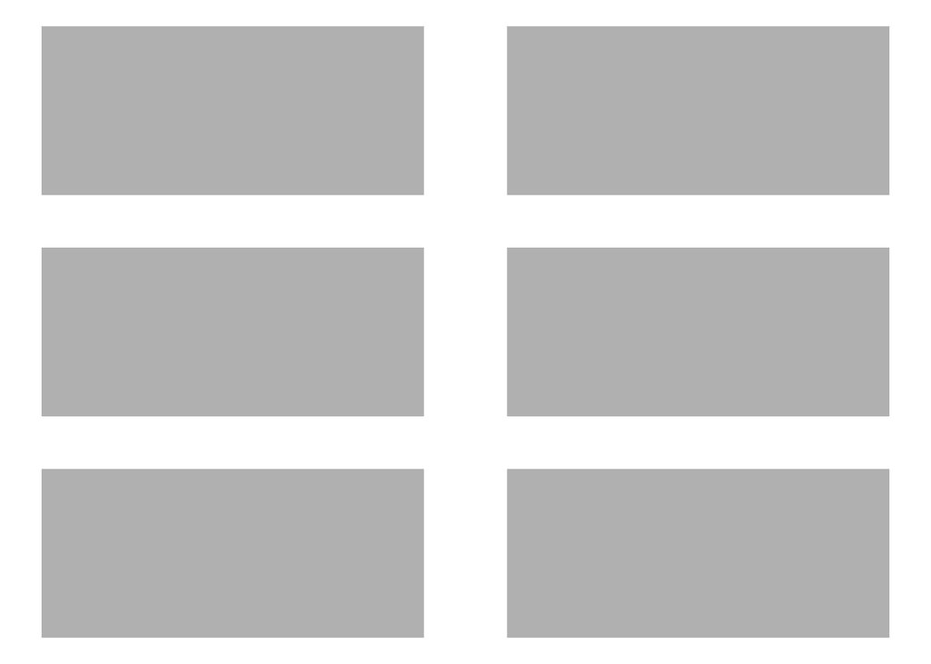

```r
# plot more rows to see what happens
par(mfrow=c(3,2), mai= c(0.2, 0.2, 0.2, 0.2))
for(i in 1:10){
    barplot(unlist(m55[i, -1]), ylim=c(0, 5), space=0, border=NA, xaxt="n", yaxt="n")
}
```

[figure not shown]

```r
# plot all subplots in a figure
```

## 9.7 Plotting m55

```r
# nrow() to check number of row of m55.
nrow(m55)
```

```
## [1] 18
```

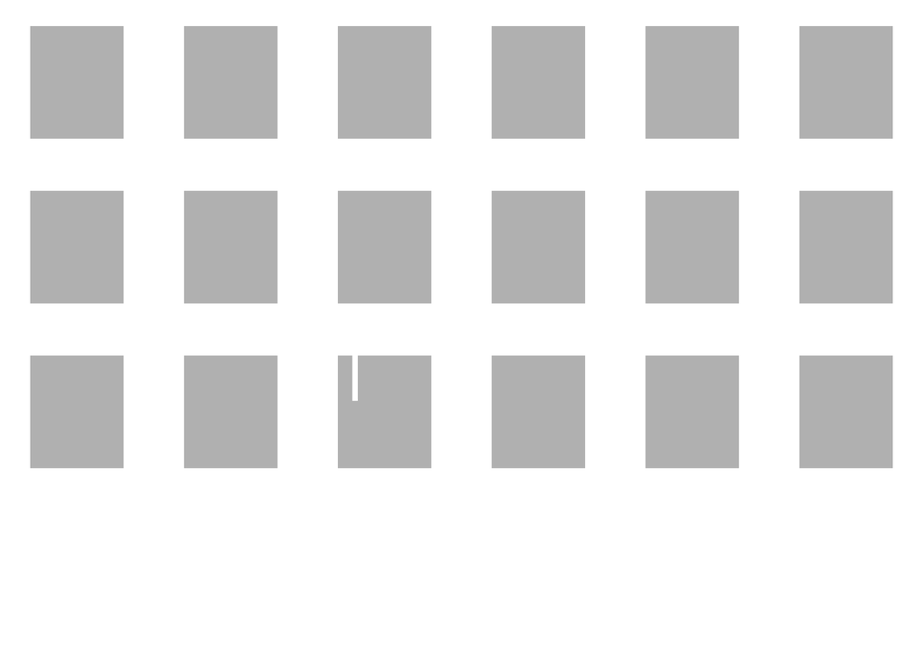

```r
# use par() to set-up plotting parameters.
par(mfrow=c(4, 6), mai= c(0.2, 0.2, 0.2, 0.2))

# use for-loop to plot all graph as subgraph
for (i in 1:nrow(m55)){
  barplot(unlist(m55[i, -1]), border=NA, space=0, xaxt="n", yaxt="n", ylim = c(0,5))
}
```

## 9.8 Adding title to each sub-plot

```r
par(mfrow=c(4,6), mai= c(0.2, 0.2, 0.2, 0.2))
for (i in 1:nrow(m55)){
    barplot(unlist(m55[i, -1]), border=NA, space=0,xaxt="n", yaxt="n", ylim = c(0,5))
    title(m55[i,1], line = -4, cex.main=3)
}
```

[output not shown]

# 10 Practice02_1_1 Plotting more

```r
# plotting matleave_95 != 5 but matleve_13 == 5

# plotting for matleave_13 == 4
```

# 11 Practice02_2_2 selecting and filtering by dplyr I

```r
df <- read_excel("data/WORLD-MACHE_Gender_6.8.15.xls", "Sheet1", col_names=T)

# select columns by index
# matleave <- df[ , c(3, 6:24)]

# select all NA cells and assign 0 to them
# matleave[is.na(matleave)] <- 0

# filter rows by condition
# m5 <- matleave[matleave$'matleave_13' == 5, ]

# filter rows by condition
# m55<- m5[m5$'matleave_95' == 5,]

# plot
par(mfrow=c(4,6), mai= c(0.2, 0.2, 0.2, 0.2))
for (i in c(1:nrow(m55))){
    barplot(unlist(m55[i,-1]),
            border=NA, space=0,xaxt="n", yaxt="n", ylim = c(0,5))
    title(m55[i,1], line = -4, cex.main=3)
}
```

[output not shown]

# 12 (More) Clean version

```r
# readxl::read_excel() to import the xls file
df <- read_excel("data/WORLD-MACHE_Gender_6.8.15.xls", "Sheet1", col_names=T)

# select iso3, and matleave columns by index
matleave <- df[ , c(3, 6:24)]

# str() to inspect the data structure of
str(matleave)
```

```
## Classes 'tbl_df', 'tbl' and 'data.frame':    197 obs. of  20 variables:
##  $ iso3       : chr  "AFG" "ALB" "DZA" "AND" ...
##  $ matleave_95: num  2 5 3 2 2 2 2 3 1 5 ...
##  $ matleave_96: num  2 5 3 2 2 2 2 3 1 5 ...
##  $ matleave_97: num  2 5 3 2 2 2 2 3 1 5 ...
##  $ matleave_98: num  2 5 3 2 2 2 2 3 1 5 ...
##  $ matleave_99: num  2 5 3 2 2 2 2 3 1 5 ...
##  $ matleave_00: num  2 5 3 3 2 2 2 3 1 5 ...
##  $ matleave_01: num  2 5 3 3 2 2 2 3 1 5 ...
##  $ matleave_02: num  2 5 3 3 2 2 2 3 1 5 ...
##  $ matleave_03: num  2 5 3 3 2 2 2 3 1 5 ...
##  $ matleave_04: num  2 5 3 3 2 2 2 5 1 5 ...
##  $ matleave_05: num  2 5 3 3 2 2 2 5 1 5 ...
##  $ matleave_06: num  2 5 3 3 2 2 2 5 1 5 ...
##  $ matleave_07: num  2 5 3 3 2 2 2 5 1 5 ...
##  $ matleave_08: num  2 5 3 3 2 2 2 5 1 5 ...
##  $ matleave_09: num  2 5 3 3 2 2 2 5 1 5 ...
##  $ matleave_10: num  2 5 3 3 2 2 2 5 NA 5 ...
##  $ matleave_11: num  2 5 3 3 2 2 2 5 3 5 ...
##  $ matleave_12: num  2 5 3 3 2 2 2 5 3 5 ...
##  $ matleave_13: num  2 5 3 3 2 2 2 5 3 5 ...
```

```r
# select all NA cells and assign 0 to them
matleave[is.na(matleave)] <- 0

# filter rows by condition
m5 <- matleave[matleave$'matleave_13' == 5, ]

# filter rows by condition
m55<- m5[m5$'matleave_95' == 5,]

# plot
par(mfrow=c(4,6), mai= c(0.2, 0.2, 0.2, 0.2))
for (i in c(1:nrow(m55))){
    barplot(unlist(m55[i,-1]),
            border=NA, space=0,xaxt="n", yaxt="n", ylim = c(0,5))
    title(m55[i,1], line = -4, cex.main=3)
}
```

[output not shown]

# 13 (More) The fittest version to compute staySame

```r
# staySame version
# staySame <- apply(m5[,2:20], 1, function(x) length(unique(x[!is.na(x)])))
# m55 <- m5[staySame, ]
# m50 <- m5[!staySame, ]
```

# 14 by dplyr

```r
library(dplyr)
```

```r
library(tidyr)
library(ggplot2)
raw <- read_excel("data/WORLD-MACHE_Gender_6.8.15.xls", "Sheet1", col_names=T)
matleave <- select(raw, iso3, 6:24)
m5 <- filter(matleave, matleave_13==5)
m55 <- filter(m5, matleave_95==5)
```

# 15 by dplyr + pipeline

```r
m55 <- read_excel("data/WORLD-MACHE_Gender_6.8.15.xls", "Sheet1", col_names=T) %>%
    select(iso3, 6:24) %>%
    filter(matleave_13==5) %>%
    filter(matleave_95==5)
```

# 16 by dplyr + pipeline + ggplot2

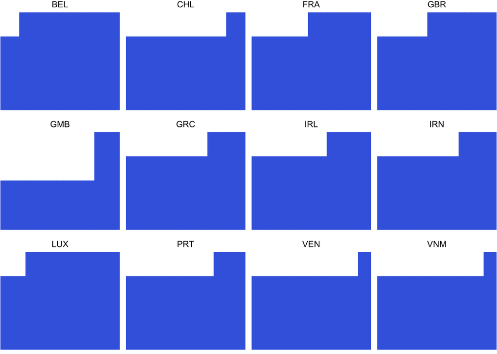

```r
library(dplyr)
library(tidyr)
library(ggplot2)

read_excel("data/WORLD-MACHE_Gender_6.8.15.xls", "Sheet1", col_names=T) %>%
    select(iso3, contains("matleave"), -contains("wrr")) %>%
    filter(matleave_13==4, matleave_95!=4) %>%
    gather("year", "degree", 2:20) %>%
    replace_na(list(degree=0)) %>%
    mutate(year2=as.POSIXct(strptime(year, "matleave_%y"))) %>%
    mutate(year3 = strftime(year2, "%Y")) %>%
    ggplot() +
    aes(year3, degree) +
    geom_col(color="royalblue", fill="royalblue") +
    facet_wrap(~ iso3) +
    theme_void()
```